# Dependancy Diagram - 1NF

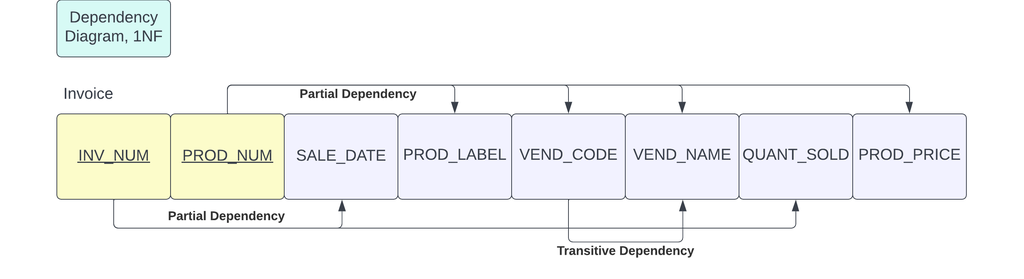

# Dependancy Diagram - 2NF

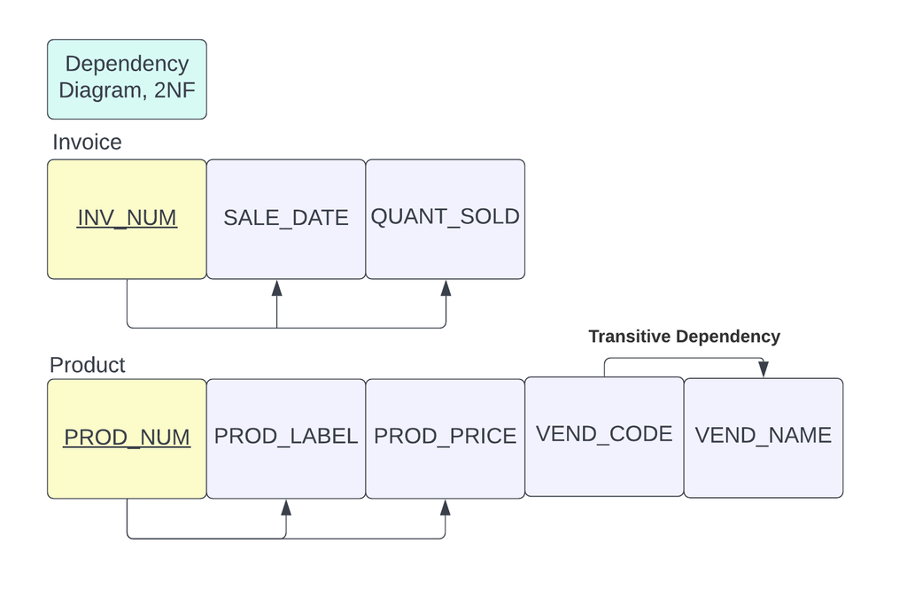

# Dependancy Diagram - 3NF

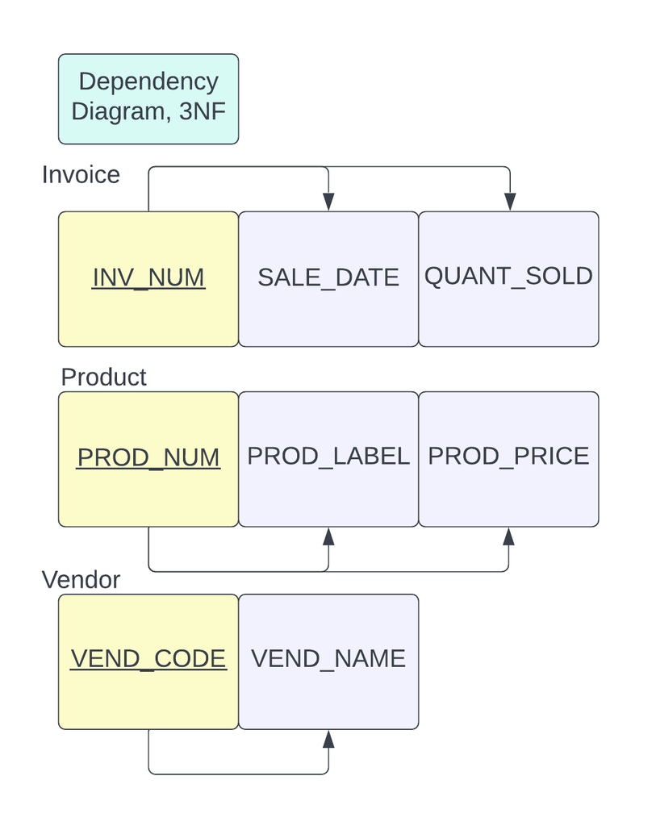

# Relational Schema - 1NF

[figure not shown]

# Relational Schema - 2NF

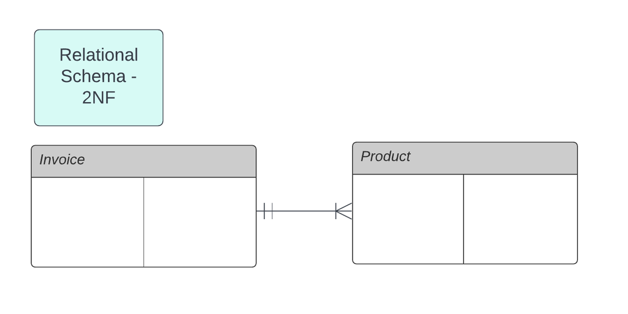

# Relational Schema - 3NF

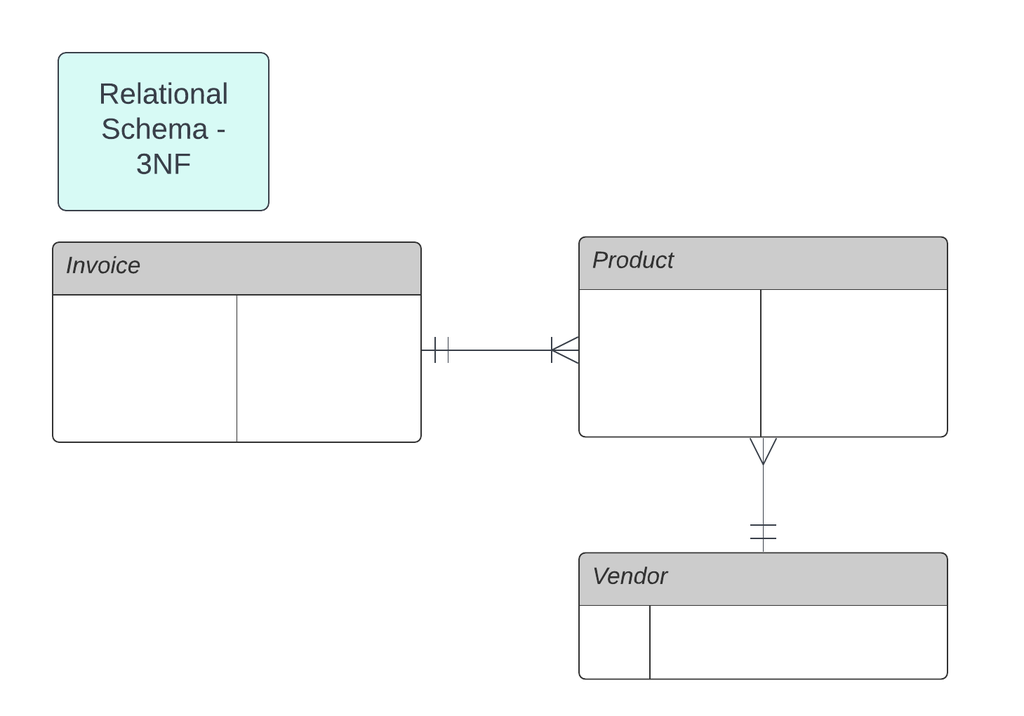

# Entity Relationship Diagram - Invoices

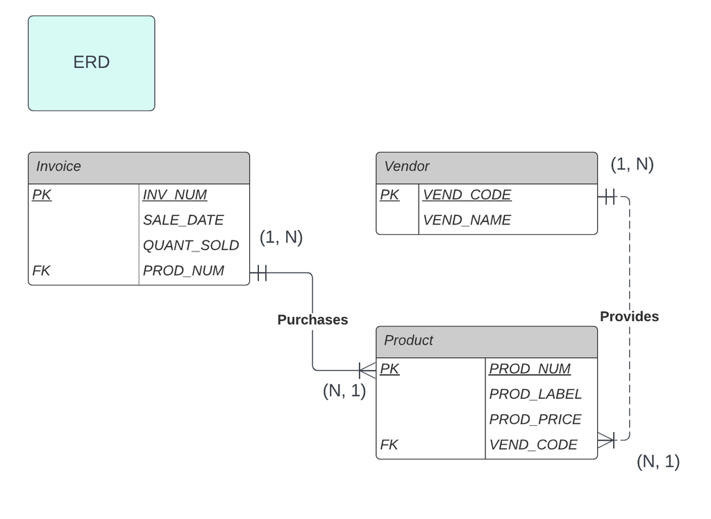

# Entity Relationship Diagram - Group Project

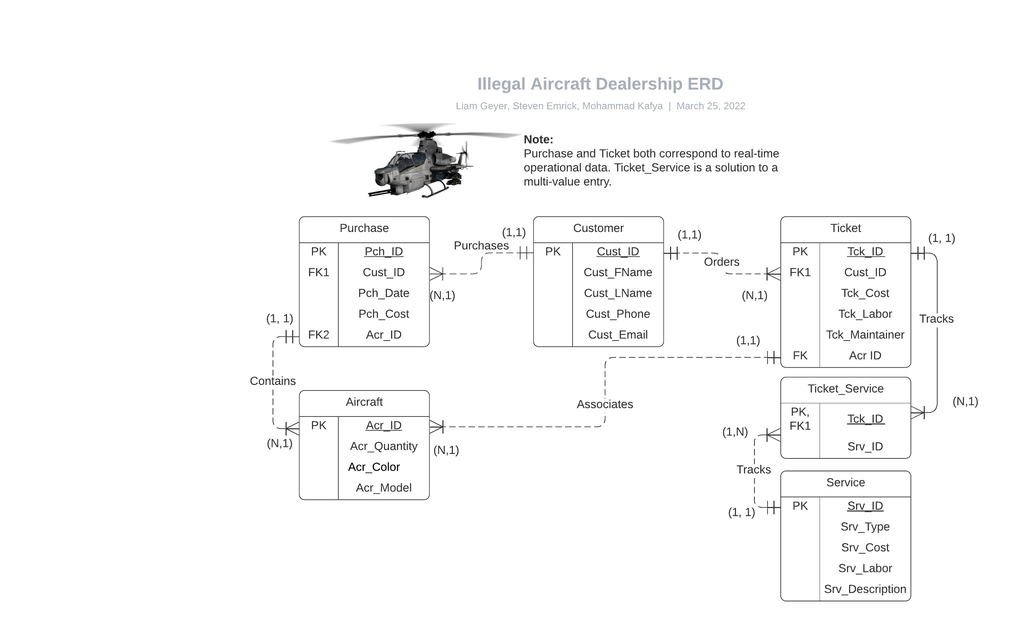

# Dependency Diagram - Group Project

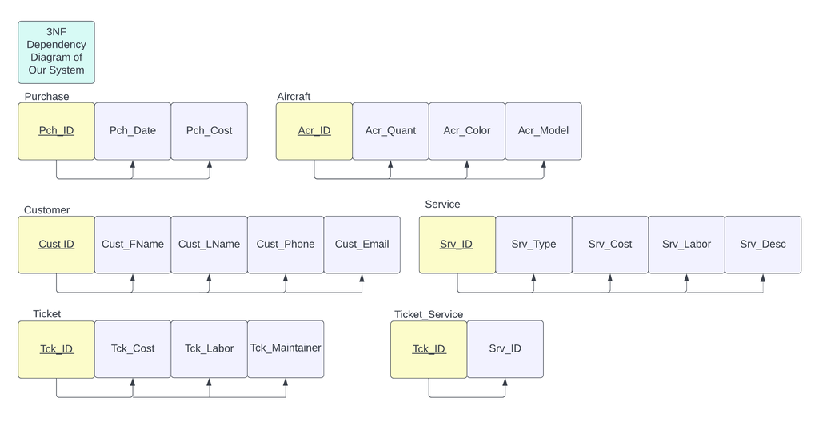

## Project Description

We were able to use the partial dependency table to dictate our relative schemas and ERD’s for each normal form. This helped us determine how to break up the partial and transitive dependencies. In the first normal form, the table was going to be based on the “inv_num” considering that would have every piece of information on it. The second normal form assisted us in breaking up the “inv_num” and “prod_num” into two separate tables with each primary key having its corresponding attributes. When converting everything to the third normal form, we were able to create another table to break up the transitive dependency of “vend_code” and “vend_name”. After completing the dependency tables, the relative schemas were very simple to make for first, second, and third normal form. In the end, we were left with three tables that would allow us to make easy decisions on connectivity and cardinality during the third normal form ERD-making process. We decided to make the “vendor” table a foreign key in the “product” table because a product would have a vendor code along with other attributes. Commonly speaking, one vendor code could associate with multiple products considering most companies sell multiple products. For the “invoice” table, it would use the “product” table as a foreign key because the invoice would have all the information on it. One invoice ticket could have multiple products on it. The final layout was the “vendor” table connecting with the “product’ table and the “product” table connecting with the “invoice” table.